# Domača naloga 6

Linearni modeli

Alen Kahteran

21. 01. 2020

## Leska

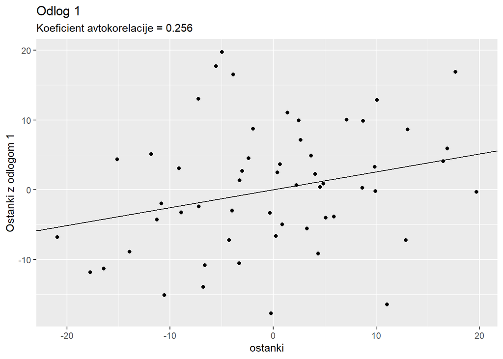

```r
# linear model
mod.lm <- lm(cvet.dan~temp, data=leska)

# get residuals
residuals_LM <- resid(mod.lm)

# remove names
names(residuals_LM) <- NULL

# calculated lag correlations
autocor <- acf(residuals(mod.lm), plot=FALSE)

corr1 <- autocor[1]$acf[1]
corr2 <- autocor[2]$acf[1]
corr3 <- autocor[3]$acf[1]

# testing
# cor(residuals_LM, dplyr::lag(residuals_LM, 1), use="pairwise.complete.obs")
# cor(residuals_LM, dplyr::lag(residuals_LM, 2), use="pairwise.complete.obs")
# cor(residuals_LM, dplyr::lag(residuals_LM, 3), use="pairwise.complete.obs")
#
# lm(dplyr::lag(residuals_LM, 1) ~ residuals_LM)
# lm(dplyr::lag(residuals_LM, 2) ~ residuals_LM)
# lm(dplyr::lag(residuals_LM, 3) ~ residuals_LM)

g <- ggplot(mapping=aes(x=residuals_LM))

g + geom_point(aes(y=dplyr::lag(residuals_LM, 1))) +
    geom_abline(slope = corr1) +
    labs(x="ostanki",
         y="Ostanki z odlogom 1",
         title="Odlog 1",
         subtitle=paste("Koeficient avtokorelacije =", round(corr1, 3)))
```

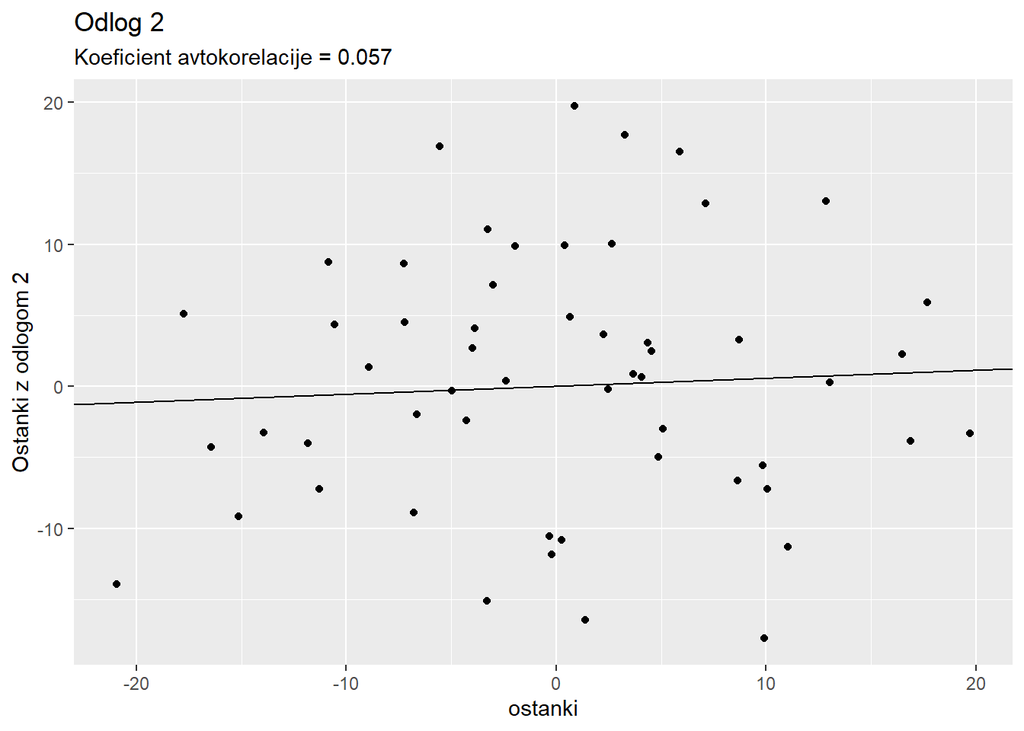

```r
g + geom_point(aes(y=dplyr::lag(residuals_LM, 2))) +
    geom_abline(slope = corr2) +
    labs(x="ostanki",
         y="Ostanki z odlogom 2",
         title="Odlog 2",
         subtitle=paste("Koeficient avtokorelacije =", round(corr2, 3)))
```

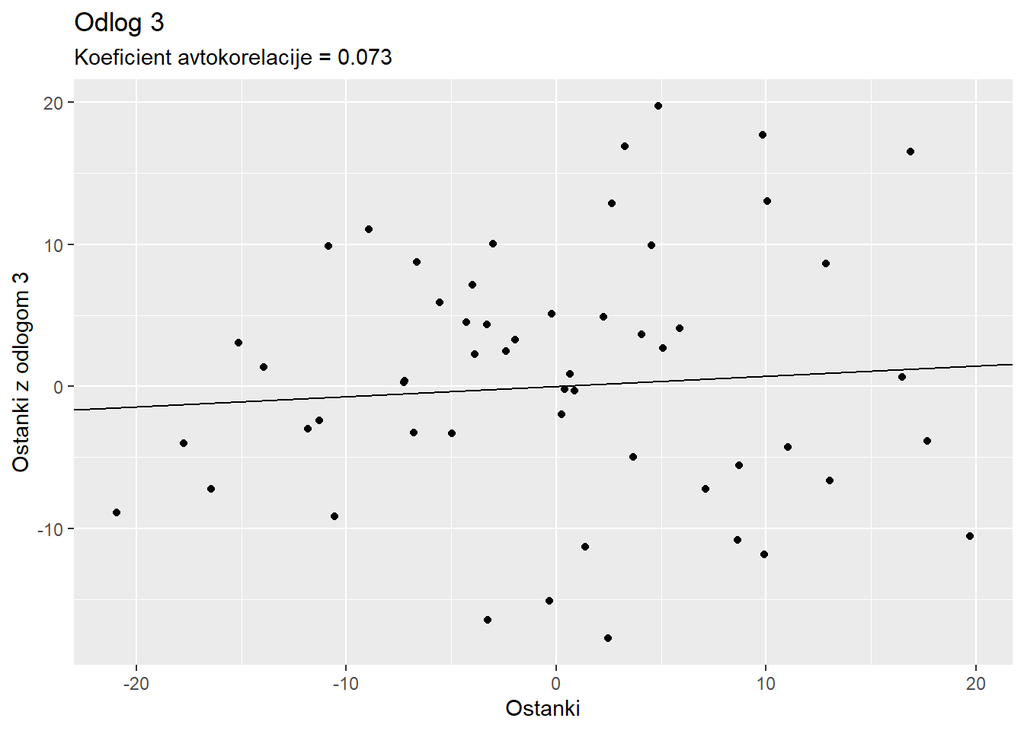

```r
g + geom_point(aes(y=dplyr::lag(residuals_LM, 3))) +
    geom_abline(slope = corr3) +
    labs(x="Ostanki",
         y="Ostanki z odlogom 3",
         title="Odlog 3",
         subtitle=paste("Koeficient avtokorelacije =", round(corr3, 3)))
```

Iz teh grafov bi lahko rekli da odlog 1 predstavlja nekaj težave, kar smo videli tudi že na vajah z Durbin-Watson testom.

```r
(DWT1<-durbinWatsonTest(mod.lm, max.lag=5))
```

```
##  lag Autocorrelation D-W Statistic p-value
##    1      0.25626565      1.395108   0.016
##    2      0.05677640      1.767396   0.446
##    3      0.07264266      1.691793   0.380
##    4      0.11079895      1.552026   0.184
##    5      0.07882800      1.590820   0.286
##  Alternative hypothesis: rho[lag] != 0
```

## Kardiovaskularna smrtnost

Najprej ustrezno pripravimo čas.

```r
data_cardio <- lap
time_ <- (time(cmort) - 1970)*52

data_cardio <- cbind(data_cardio, time_)
```

Zanima nas kako na kardiovaskularno smrtnost (`cmort`) vplivata tmpratura zraka (`tempr`) in onesnaženost s prašnimi delci (`part`). Zato ustvarimo primeren linearni model in si poglejmo če so izpolnjene predpostavke linearnega modela.

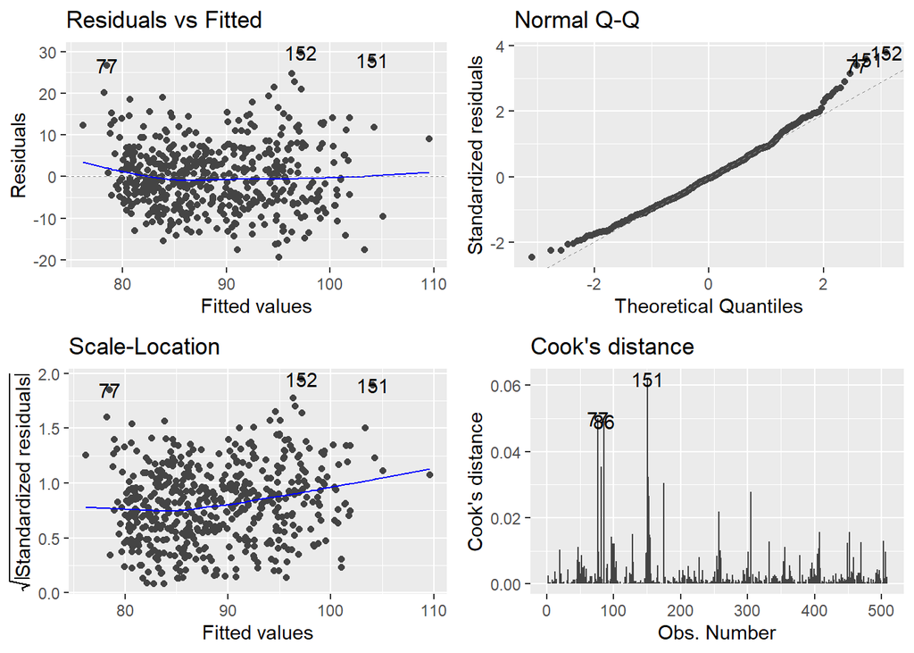

```r
mod_lm <- lm(data_cardio.cmort ~ data_cardio.tempr + data_cardio.part, data=data_cardio)

autoplot(mod_lm, which=1:4)
```

Večjih težav ni videti, mogoče le nekoliko pri repih na Q-Q prikazu, vendar nič hujšega. Če si pogledamo še časovno vrsto ostankov, bomo videli če imamo težavo z avtokorelacijo.

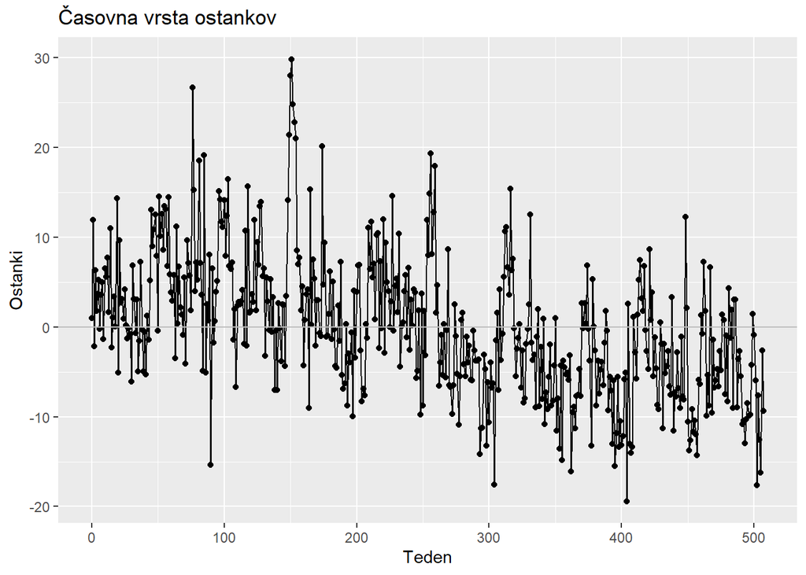

```r
ggplot(mapping=aes(x=time_, y=resid(mod_lm))) +
    geom_point() +
    geom_line() +
    geom_hline(yintercept = 0, col="gray") +
    labs(title = "Časovna vrsta ostankov",
         x="Teden",
         y="Ostanki")
```

Videti je da imamo več zaporednih točk pozitivnih nato negativnih, kar lahko predstavlja težave z avtokorelacijo. Preverimo rezultate Durbin-Watson testa

```r
durbinWatsonTest(mod_lm, max.lag=5)
```

```
##  lag Autocorrelation D-W Statistic p-value
##    1       0.5379932     0.9211727       0
##    2       0.5882456     0.8158950       0
##    3       0.4653933     1.0530453       0
##    4       0.4572644     1.0630064       0
##    5       0.3683894     1.2387908       0
##  Alternative hypothesis: rho[lag] != 0
```

Vidimo da je prvih 5 odlogov statistično značilnih, ker nam to ne pove veliko si poglejmo ACF in PACF grafe.

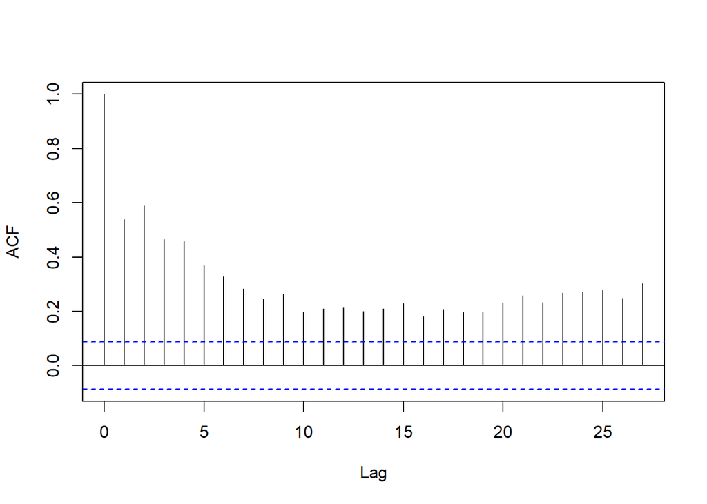

```r
acf(residuals(mod_lm), main="")
```

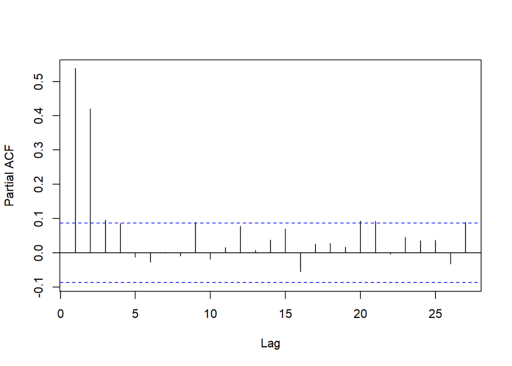

```r
pacf(residuals(mod_lm), main="")
```

Vidimo da imamo težave z avtokorelacijo. Iz PACF grafa je videti da bi model z odlogom 3 ali pa celo 4 bil bolj primeren model. Pripravimo si oba modela.

```r
mod_GLS_3<-gls(data_cardio.cmort ~ data_cardio.tempr + data_cardio.part,
               correlation=corARMA(p=3),
               data=data_cardio,
               method="ML")

mod_GLS_4<-gls(data_cardio.cmort ~ data_cardio.tempr + data_cardio.part,
               correlation=corARMA(p=4),
               data=data_cardio,
               method="ML")
```

Poglejmo si če sta modela različna od osnovnega modela.

```r
anova(mod_GLS_3, mod_lm)
```

```
##           Model df      AIC      BIC    logLik   Test  L.Ratio p-value
## mod_GLS_3     1  7 3175.379 3204.992 -1580.689
## mod_lm        2  4 3542.767 3559.689 -1767.384 1 vs 2 373.3885  <.0001
```

```r
anova(mod_GLS_4, mod_lm)
```

```
##           Model df      AIC      BIC    logLik   Test  L.Ratio p-value
## mod_GLS_4     1  8 3177.377 3211.221 -1580.688
## mod_lm        2  4 3542.767 3559.689 -1767.384 1 vs 2 373.3902  <.0001
```

Vidimo da se v obeh primerih statistično značilno razlikujeta od osnovnega modela. Primerjajmo ju še med seboj.

```r
anova(mod_GLS_3, mod_GLS_4)
```

```
##           Model df      AIC      BIC    logLik   Test     L.Ratio p-value
## mod_GLS_3     1  7 3175.379 3204.992 -1580.689
## mod_GLS_4     2  8 3177.377 3211.221 -1580.688 1 vs 2 0.001706046  0.9671
```

Ne moremo trditi da sta statistično značilno drugačna modela. Sicer ima model z odlogom 3 malenkost boljši AIC in BIC vrednosti, vendar očitno premalo da bi bilo statistično značilno. Torej nadaljujmo z modelom z odlogom 3.

```r
summary(mod_GLS_3)
```

```
## Generalized least squares fit by maximum likelihood
##   Model: data_cardio.cmort ~ data_cardio.tempr + data_cardio.part
##   Data: data_cardio
##        AIC      BIC    logLik
##   3175.379 3204.992 -1580.689
##
## Correlation Structure: ARMA(3,0)
##  Formula: ~1
##  Parameter estimate(s):
##      Phi1      Phi2      Phi3
## 0.4172070 0.4215115 0.0329413
##
## Coefficients:
##                      Value Std.Error   t-value p-value
## (Intercept)       79.95606  3.377086 23.676050  0.0000
## data_cardio.tempr  0.03149  0.046235  0.680993  0.4962
## data_cardio.part   0.13729  0.026728  5.136760  0.0000
##
##  Correlation:
##                   (Intr) dt_crd.t
## data_cardio.tempr -0.782
## data_cardio.part   0.241 -0.612
##
## Standardized residuals:
##         Min          Q1         Med          Q3         Max
## -2.06712975 -0.72907604 -0.09235027  0.56811042  4.32203323
##
## Residual standard error: 9.363739
## Degrees of freedom: 508 total; 505 residual
```

Torej če še interpretiramo koeficiente

- Vidimo da je kardiovaskularna smrtnost statistično značilno odvisna od prašnih delcev (ob upoštevanju temperature) - $p<0.0001$. Če se v povprečju vrednost prašnih delcev poveča za 1 enoto (ob upoštevanju temperature), se kardiovaskularna smrtnost poveča za $0.137$.
- Ne moremo trditi da je kardiovaskularna smrtnost odvisna od temperature (ob upoštevanju prašnih delcev) - $p<0.4962$. Če se v povprečju temperatura poveča za 1 stopinjo Fahrenheita (ob upoštevanju prašnih delcev), se kardiovaskularna smrtnost poveča za $0.031$.
- $\beta_0$ bi, v primeru ko bi imelu podatke blizu 0 Fahrenheit in 0 prašnih delcev, lahko interpretirali kot da je smrtnost v povprečju enaka $79.96$.